# Problem One:

### Comment:

Linear relationships: Displacement and Horsepower (positive linear), Horsepower and Weight (positive linear), Displacement and weight (positive linear), horsepower and acceleration (potentially negative linear), displacement and acceleration (potentially negative linear)

Plots highlighting some of the above relationships:

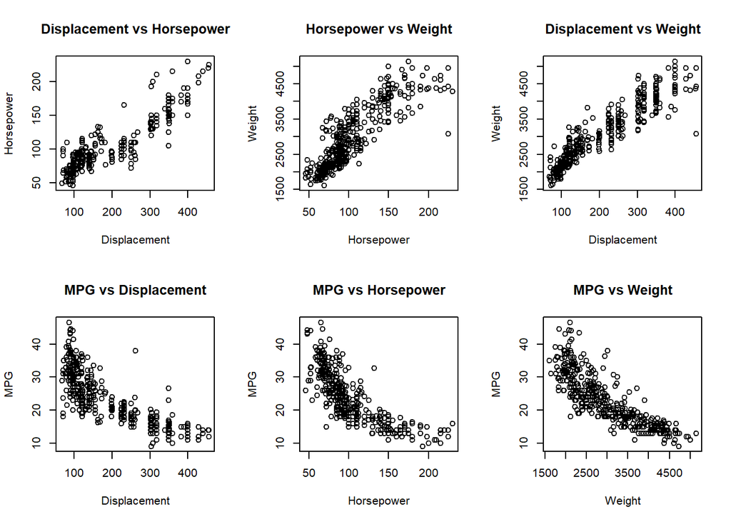

```r
### Linear relationships

par(mfrow = c(2, 3))
# Displacement and Horsepower
plot(auto_quant$displacement, auto_quant$horsepower, main="Displacement vs Horsepower",
     xlab="Displacement", ylab="Horsepower")

# Horsepower and Weight
plot(auto_quant$horsepower, auto_quant$weight, main="Horsepower vs Weight",
     xlab="Horsepower", ylab="Weight")

# Displacement and Weight
plot(auto_quant$displacement, auto_quant$weight, main="Displacement vs Weight",
     xlab="Displacement", ylab="Weight")

# non-linear Relationships

# mpg and displacement
plot(auto_quant$displacement, auto_quant$mpg, main="MPG vs Displacement",
     xlab="Displacement", ylab="MPG")

# mpg and horsepower
plot(auto_quant$horsepower, auto_quant$mpg, main="MPG vs Horsepower",
     xlab="Horsepower", ylab="MPG")

# mpg and weight
plot(auto_quant$weight, auto_quant$mpg, main="MPG vs Weight",
     xlab="Weight", ylab="MPG")
```

6. Suppose that we wish to predict gas mileage (mpg) on the basis of the other variables. Do your plots suggest that any of the other variables might be useful in predicting mpg? Justify your answer.

### Comment:

I kind of already did this above, but the important variables for predicting mpg would be displacement, horsepower, and weight. All 3 of those have a non-linear relationship with MPG that can be seen in the plots generated above.

# Problem Five:

This question involves the use of simple and multiple linear regression on the Auto data set.

1. Use the `lm()` function to perform a simple linear regression with mpg as the response and horsepower as the predictor. Use the `summary()` function to print the results. Comment on the output.

```r
linear_model <- lm(mpg ~ horsepower, data=auto_quant)
summary(linear_model)
```

```
##
## Call:
## lm(formula = mpg ~ horsepower, data = auto_quant)
##
## Residuals:
##      Min       1Q   Median       3Q      Max
## -13.5710  -3.2592  -0.3435   2.7630  16.9240
##
## Coefficients:
##              Estimate Std. Error t value Pr(>|t|)
## (Intercept) 39.935861   0.717499   55.66   <2e-16 ***
## horsepower  -0.157845   0.006446  -24.49   <2e-16 ***
## ---
## Signif. codes:  0 '***' 0.001 '**' 0.01 '*' 0.05 '.' 0.1 ' ' 1
##
## Residual standard error: 4.906 on 390 degrees of freedom
## Multiple R-squared:  0.6059, Adjusted R-squared:  0.6049
## F-statistic: 599.7 on 1 and 390 DF,  p-value: < 2.2e-16
```

For example: i. Is there a relationship between the predictor and the response? ii. How strong is the relationship between the predictor and the response? iii. Is the relationship between the predictor and the response positive or negative? iv. What is the predicted mpg associated with a horsepower of 98? What are the associated 95% confidence and prediction intervals?

### Comment:

1. p-value: 2e-16 = very low (< 0.05) indicating there is a relationship between mpg and horsepower
2. adjusted R-squared: 0.6049 indicates a decent relationship but not extremely strong (would need to be closer to 1)
3. negative since coefficient for horsepower is -0.157845
4. mpg=39.935861−0.157845×horsepower is the equation - plugging in 98 gets you: 24.47 mpg
2. Plot the response and the predictor. Use the `abline()` function to display the least squares regression line.

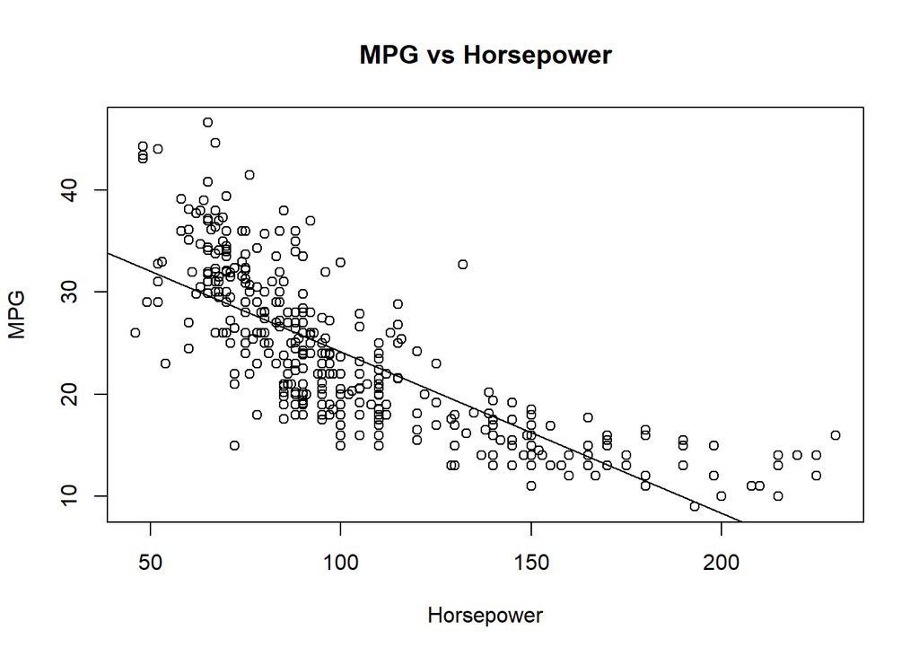

```r
plot(auto_quant$horsepower, auto$mpg, main="MPG vs Horsepower", xlab="Horsepower", ylab="MPG")
abline(linear_model)
```

```r
# Linear doesn't appear like the best choice for fitting the data
```

3. Use the `plot()` function to produce diagnostic plots of the least squares regression fit. Comment on any problems you see with the fit.

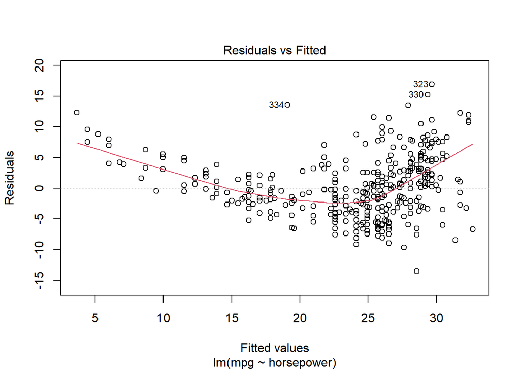

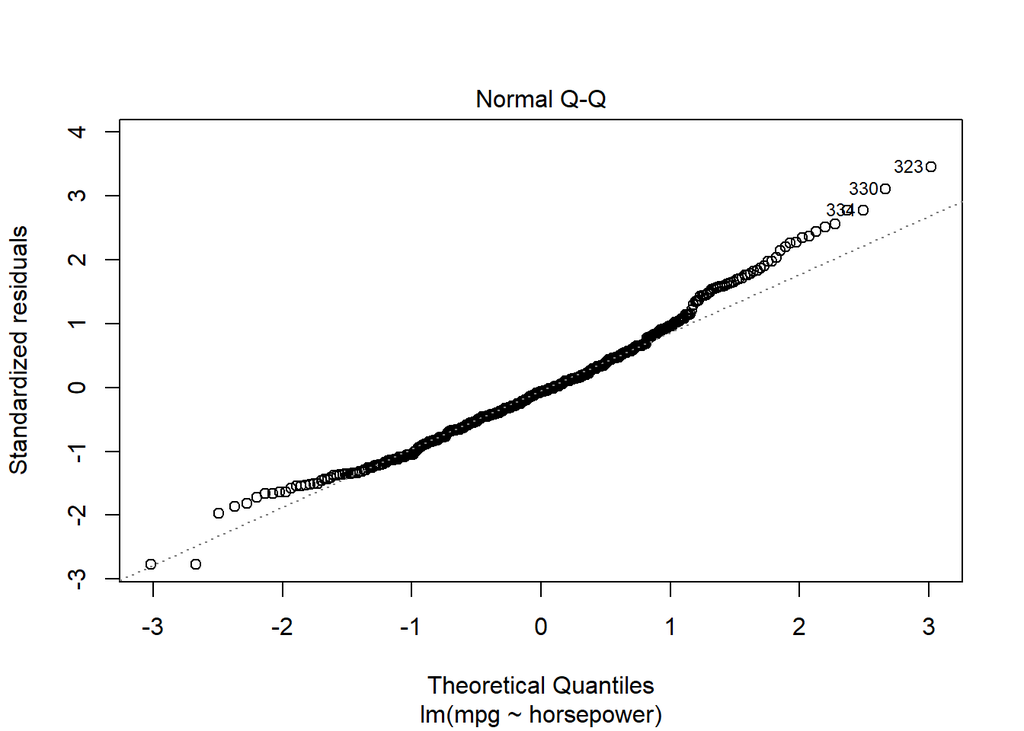

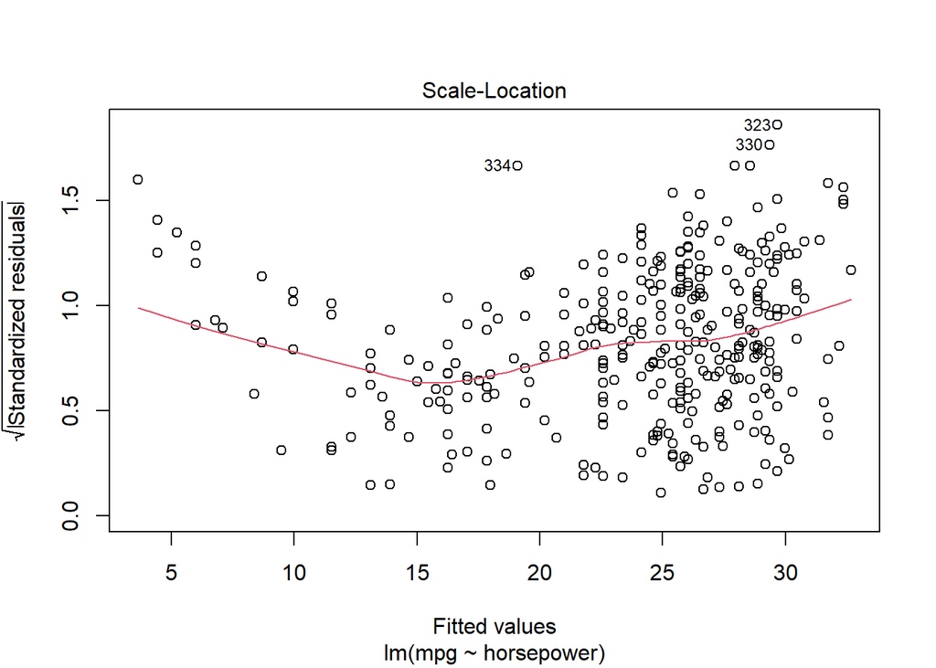

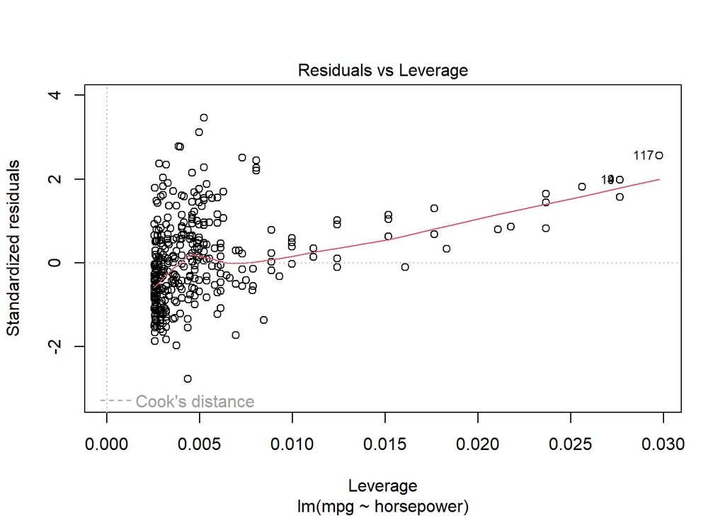

```r
plot(linear_model)
```